# Starting with Data

**Learning Objectives**

- Describe what the `here` package does
- Read in tibbles
- Compare `read_csv` to `read.csv`
- Extract values from tibbles
- Perform basic operations on columns in a tibble.

Data dictionary.

| Column | Description |
| --- | --- |
| sample | clone name |
| generation | generation when sample frozen |
| clade | based on a parsimony tree |
| strain | ancestral strain |
| cit | citrate-using mutant status |
| run | sequence read archive sample ID |
| genome_size | size in Mbp (made up for this lesson) |

Note this type of information is often called *metadata* and this table refereed to as a *data dictionary*.

First we are going to download the metadata file using the `download.file()` function and the `here` function.

### The here package

See posts by [Jenny Bryan](https://github.com/jennybc/here_here) and [Malcolm Barrett](https://malco.io/2018/11/05/why-should-i-use-the-here-package/)

RStudio projects let us set up a local working directory, which makes it easier for someone else to access your files with the same folder and file structure.  
The `here` package lets us write file paths that work across operating systems: it detects the root directory and writes lets us build paths accordingly. Within a RProject the root directory where your `*.Rproj` file is. This is one reason why for each project you should only have one `*.Rproj` file.

```r
getwd()   #  prints out my working directory
```

```
## [1] "/Users/acgerstein/Documents/Umanitoba/Teaching/2019-MBIO7040/MBIO7040-UManitoba/scripts"
```

```r
dir()     #  prints out what is in my working directory
```

```
##  [1] "00-Setup.html"             "00-Setup.Rmd"
##  [3] "01-Spreadsheets.html"      "01-Spreadsheets.Rmd"
##  [5] "02-Intro.html"             "02-Intro.Rmd"
##  [7] "03-R_Start.html"           "03-R_Start.Rmd"
##  [9] "04-Data_Start_b.txt"       "04-Data_Start.html"
## [11] "04-Data_Start.Rmd"         "04-Load_Data.html"
## [13] "04-Load_Data.Rmd"          "05-dplyr.html"
## [15] "05-dplyr.Rmd"              "06-introStats.html"
## [17] "06-introStats.Rmd"         "06-plotting-i-b.txt"
## [19] "06-plotting-i.html"        "06-plotting-i.nb.html"
## [21] "07-EDA-i.Rmd"              "190407_GeneExpression.Rmd"
## [23] "hideOutput.css"            "hideOutput.js"
## [25] "index.html"                "index.Rmd"
## [27] "script.R"                  "style.css"
```

```r
library(here) #  load the here package
```

Importantly, this allows us to read and write files based on the working directory at the time when the package was loaded, i.e., the place where the `*.Rproj` file is.

```r
library(here)
library(tidyverse)
download.file("https://raw.githubusercontent.com/datacarpentry/R-genomics/gh-pages/data/Ecoli_metadata.csv",
here("data_in", "Ecoli_citrate.csv"))
here("data_in", "Ecoli_citrate")
```

```
## [1] "/Users/acgerstein/Documents/Umanitoba/Teaching/2019-MBIO7040/MBIO7040-UManitoba/data_in/Ecoli_citrate"
```

```r
Ecoli_citrate <- read_csv(here("data_in", "Ecoli_citrate.csv"))
```

```r
Ecoli_citrate
```

```
## # A tibble: 30 x 7
##    sample   generation clade   strain cit     run       genome_size
##    <chr>         <dbl> <chr>   <chr>  <chr>   <chr>           <dbl>
##  1 REL606            0 <NA>    REL606 unknown <NA>             4.62
##  2 REL1166A       2000 unknown REL606 unknown SRR098028        4.63
##  3 ZDB409         5000 unknown REL606 unknown SRR098281        4.6
##  4 ZDB429        10000 UC      REL606 unknown SRR098282        4.59
##  5 ZDB446        15000 UC      REL606 unknown SRR098283        4.66
##  6 ZDB458        20000 (C1,C2) REL606 unknown SRR098284        4.63
##  7 ZDB464*       20000 (C1,C2) REL606 unknown SRR098285        4.62
##  8 ZDB467        20000 (C1,C2) REL606 unknown SRR098286        4.61
##  9 ZDB477        25000 C1      REL606 unknown SRR098287        4.65
## 10 ZDB483        25000 C3      REL606 unknown SRR098288        4.59
## # … with 20 more rows
```

### EXERCISE

Using the GUI interface:  
1. Go to the Files panel of RStudio.  
2. Navigate to the directory i.e. folder on your computer where the downloaded `Ecoli_citrate.csv` file is saved.  
3. Click on Ecoli_citrate.csv  
4. Click “Import Dataset…”

At this point you should see an image like this:

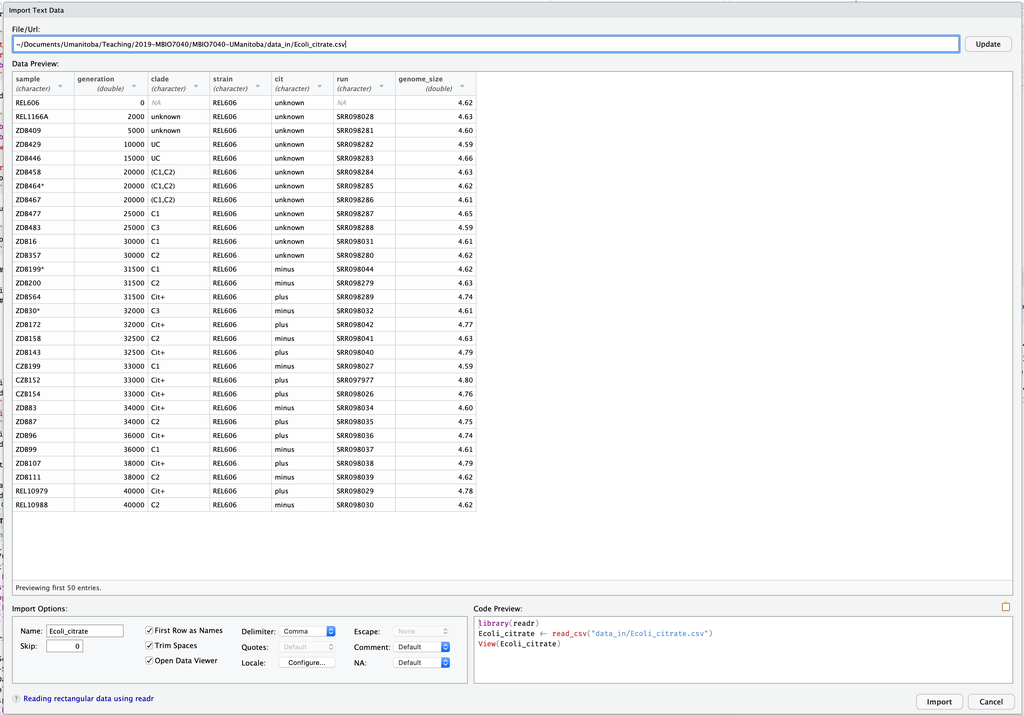

After clicking on the “Import” button on the bottom right RStudio, RStudio will save this spreadsheet’s data in a data frame called `Ecoli_citrate` and display its contents in the spreadsheet viewer. Furthermore, note in the bottom right of the above image there exists a “Code Preview”: you can copy and paste this code to reload your data again later automatically instead of repeating the above manual point-and-click process.

Note that both methods have imported the data as a tibble (if you copied the code from the Code Preview you’ll note that it used `read_csv` just like we did). Just for fun we can compare this to the same file loaded using `read.csv()`:

```r
Ecoli_citrate2 <- read.csv(here("data_in", "Ecoli_citrate.csv"))
head(Ecoli_citrate2)
```

```
##     sample generation   clade strain     cit       run genome_size
## 1   REL606          0    <NA> REL606 unknown                  4.62
## 2 REL1166A       2000 unknown REL606 unknown SRR098028        4.63
## 3   ZDB409       5000 unknown REL606 unknown SRR098281        4.60
## 4   ZDB429      10000      UC REL606 unknown SRR098282        4.59
## 5   ZDB446      15000      UC REL606 unknown SRR098283        4.66
## 6   ZDB458      20000 (C1,C2) REL606 unknown SRR098284        4.63
```

Notice that I’ve used `head`, which gives me only the first 6 rows of the data sheet. What happens if you type `Ecoli_citrate2` into the console? Note that this is different than when we read in `Ecoli_citrate2` as a tibble. There will be some applications in the future where we will need to use data frames instead of tibbles. We can easily convert between them using `as.data.frame` or `as_tibble`:

```r
Ecoli_citrate2 <- as_tibble(Ecoli_citrate2)
Ecoli_citrate2
```

```
## # A tibble: 30 x 7
##    sample   generation clade   strain cit     run       genome_size
##    <fct>         <int> <fct>   <fct>  <fct>   <fct>           <dbl>
##  1 REL606            0 <NA>    REL606 unknown ""               4.62
##  2 REL1166A       2000 unknown REL606 unknown SRR098028        4.63
##  3 ZDB409         5000 unknown REL606 unknown SRR098281        4.6
##  4 ZDB429        10000 UC      REL606 unknown SRR098282        4.59
##  5 ZDB446        15000 UC      REL606 unknown SRR098283        4.66
##  6 ZDB458        20000 (C1,C2) REL606 unknown SRR098284        4.63
##  7 ZDB464*       20000 (C1,C2) REL606 unknown SRR098285        4.62
##  8 ZDB467        20000 (C1,C2) REL606 unknown SRR098286        4.61
##  9 ZDB477        25000 C1      REL606 unknown SRR098287        4.65
## 10 ZDB483        25000 C3      REL606 unknown SRR098288        4.59
## # … with 20 more rows
```

```r
Ecoli_citrate2 <- as.data.frame(Ecoli_citrate2)
head(Ecoli_citrate2)
```

```
##     sample generation   clade strain     cit       run genome_size
## 1   REL606          0    <NA> REL606 unknown                  4.62
## 2 REL1166A       2000 unknown REL606 unknown SRR098028        4.63
## 3   ZDB409       5000 unknown REL606 unknown SRR098281        4.60
## 4   ZDB429      10000      UC REL606 unknown SRR098282        4.59
## 5   ZDB446      15000      UC REL606 unknown SRR098283        4.66
## 6   ZDB458      20000 (C1,C2) REL606 unknown SRR098284        4.63
```

Since we don’t need this data frame, let’s remove the object from memory.

```r
rm(Ecoli_citrate2)
```

You can see what is currently being stored using `ls()`.